# US Medical Insurance Cost

The dataset is from https://www.kaggle.com/datasets/mirichoi0218/insurance; it is a pre-cleaned dataset.

This is the first portfolio project for a Codecademy course. The goal is to explore the dataset.

- Dataset overview
- Exploring the diversity of the data
- What influences the cost of medical insurance?
  - Age
  - Sex
  - Smoking
  - BMI
  - Number of children
  - Correlations
- Conclusion

```python
import pandas as pd
import seaborn as sns
import matplotlib.pyplot as plt

data = pd.read_csv('insurance.csv')

#Set up custom colors and color palettes
beige = '#EBDDBE'
maroon = '#550000'
dark_grey = '#666666'
light_green = '#96EE9C'
yellow = '#FFEC17'
dark_blue = '#001155'
red = '#BF0000'
purple = '#610054'

colors_sex = sns.color_palette([beige, maroon])
colors_smokers = sns.color_palette([dark_grey, light_green])
colors_children = sns.dark_palette(yellow, reverse=True)
```

## Dataset overview

```python
columns = list(data.columns)

print('The dataset contains {rows} rows containing data about {columns}.'
.format(
    rows = len(data),
    columns = ', '.join(columns)
    ))

print('\nSample of the data:')
data.sample(5)
```

```
The dataset contains 1338 rows containing data about age, sex, bmi, children, smoker, region, charges.

Sample of the data:
```

|  | age | sex | bmi | children | smoker | region | charges |
| --- | --- | --- | --- | --- | --- | --- | --- |
| 752 | 64 | male | 37.905 | 0 | no | northwest | 14210.53595 |
| 1022 | 47 | male | 36.080 | 1 | yes | southeast | 42211.13820 |
| 342 | 60 | female | 27.550 | 0 | no | northeast | 13217.09450 |
| 121 | 18 | male | 23.750 | 0 | no | northeast | 1705.62450 |
| 1104 | 37 | male | 29.800 | 0 | no | southwest | 20420.60465 |

```python
# Check that there are no missing data in the dataset
data.info()
```

```
<class 'pandas.core.frame.DataFrame'>
RangeIndex: 1338 entries, 0 to 1337
Data columns (total 7 columns):
 #   Column    Non-Null Count  Dtype
---  ------    --------------  -----
 0   age       1338 non-null   int64
 1   sex       1338 non-null   object
 2   bmi       1338 non-null   float64
 3   children  1338 non-null   int64
 4   smoker    1338 non-null   object
 5   region    1338 non-null   object
 6   charges   1338 non-null   float64
dtypes: float64(2), int64(2), object(3)
memory usage: 73.3+ KB
```

```python
# Summary statistics
data.describe()
```

|  | age | bmi | children | charges |
| --- | --- | --- | --- | --- |
| count | 1338.000000 | 1338.000000 | 1338.000000 | 1338.000000 |
| mean | 39.207025 | 30.663397 | 1.094918 | 13270.422265 |
| std | 14.049960 | 6.098187 | 1.205493 | 12110.011237 |
| min | 18.000000 | 15.960000 | 0.000000 | 1121.873900 |
| 25% | 27.000000 | 26.296250 | 0.000000 | 4740.287150 |
| 50% | 39.000000 | 30.400000 | 1.000000 | 9382.033000 |
| 75% | 51.000000 | 34.693750 | 2.000000 | 16639.912515 |
| max | 64.000000 | 53.130000 | 5.000000 | 63770.428010 |

## Exploring the diversity of the data

We explore the number of datapoints in different categories. We want to make sure that the dataset is well-balanced.

```
[Text(0.5, 0, 'Age'),
```

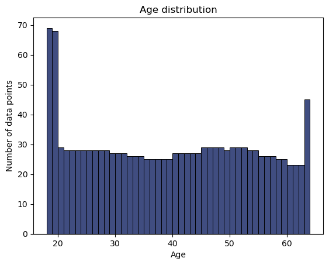

```python
# Age distribution
ax = sns.histplot(data=data, x='age', binwidth=1, color=dark_blue)
ax.set(xlabel='Age', ylabel='Number of data points',
        title='Age distribution')
```

We see that the age distribution is fairly flat, except for the ends. Let's try to create some age groups.

```
[Text(0.5, 0, 'Age'),
```

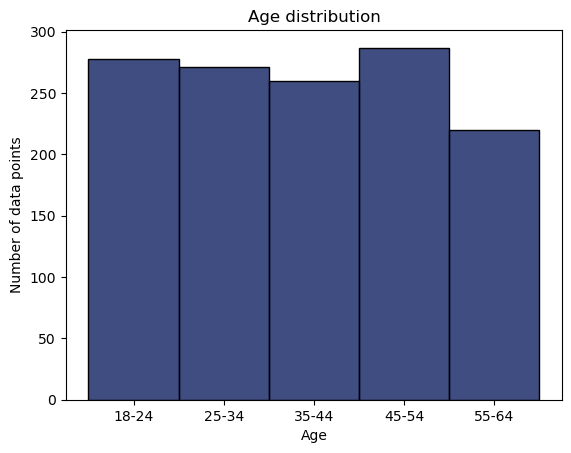

```python
# Create bins for age groups
bins_age = [18, 25, 35, 45, 55, 64]
labels_age = ['18-24', '25-34', '35-44', '45-54', '55-64']
data['age_group'] = pd.cut(data['age'], bins=bins_age,
    labels=labels_age, right=False)

# Age distribution
ax = sns.histplot(data=data, x='age_group', bins=bins_age,
                    color=dark_blue)
ax.set(xlabel='Age', ylabel='Number of data points',
        title='Age distribution')
```

We have similar number of datapoints in each age group.

Let's check if both sexes are equally represented. (Note: The dataset comes from the US and considers only two sexes.)

```
In the dataset, 49.48% of the people are women and 50.52% are men.
```

```
[Text(0.5, 0, ''),
```

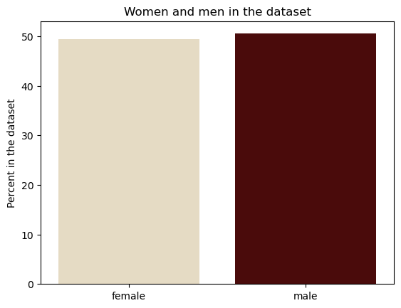

```python
# Percentage of men and women in the dataset
number_total = len(data)
number_female = len(data[data['sex'] == 'female'])
number_male = len(data[data['sex'] == 'male'])
percent_female = round(number_female/number_total*100,2)
percent_male = round(number_male/number_total*100,2)
print('In the dataset, {w}% of the people are women and {m}% are ' \
    'men.'.format(w=percent_female, m=percent_male))

ax = sns.countplot(data=data, x='sex', hue='sex', palette=colors_sex,
                    stat='percent')
ax.set(xlabel=None, ylabel='Percent in the dataset',
        title='Women and men in the dataset')
```

The dataset is well-balanced between men and women. Let's check that the same holds in each age group.

```
Number of datapoints divided by age and sex:
sex        female  male
age_group
18-24         134   144
25-34         132   139
35-44         129   131
45-54         144   143
55-64         112   108
```

```
[Text(0.5, 0, 'Age group'),
```

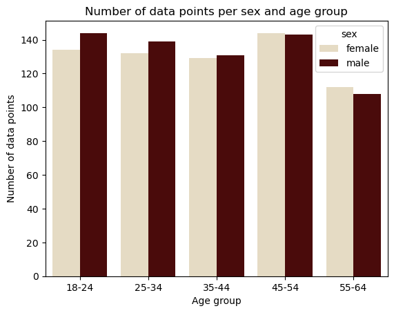

```python
# We want to check that the sex is balanced in each age group
print('\nNumber of datapoints divided by age and sex:')
print(pd.crosstab(data['age_group'], data['sex']))

ax = sns.countplot(data=data, x='age_group',
                    hue='sex', palette=colors_sex)
ax.set(xlabel='Age group', ylabel='Number of data points',
        title='Number of data points per sex and age group')
```

The balance between men and women is similar in each age group.

Next, let's look at smokers and nonsmokers.

```
In the dataset, 20.48% of the people are smokers and 79.52% are nonsmokers.
```

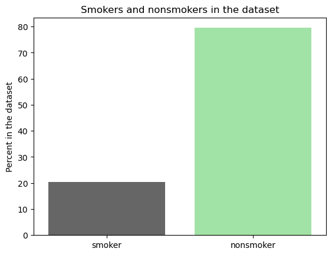

```python
# Percentage of smokers and nonsmokers in the dataset
number_total = len(data)
number_smoker = len(data[data['smoker'] == 'yes'])
number_nonsmoker = len(data[data['smoker'] == 'no'])
percent_smoker = round(number_smoker/number_total*100,2)
percent_nonsmoker = round(number_nonsmoker/number_total*100,2)
print('In the dataset, {y}% of the people are smokers and {n}% ' \
    'are nonsmokers.'.format(y=percent_smoker, n=percent_nonsmoker))

ax = sns.countplot(data=data, x='smoker', hue='smoker',
                    palette=colors_smokers, stat='percent')
ax.set(xlabel=None, ylabel='Percent in the dataset',
        title='Smokers and nonsmokers in the dataset')
ax.set_xticks([0,1], labels=['smoker', 'nonsmoker'])
```

We can also check the smoking status in each age group.

```
Number of datapoints divided by age and smoker status:
smoker      no  yes
age_group
18-24      218   60
25-34      215   56
35-44      199   61
45-54      232   55
55-64      185   35
```

```
[Text(0.5, 0, 'Age group'),
```

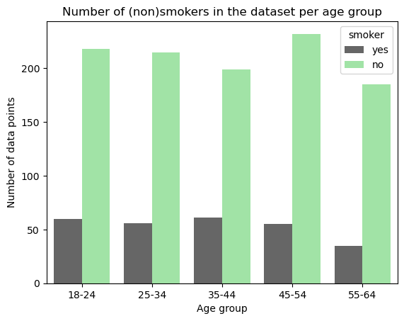

```python
# Number of data points for smokers and nonsmokers per age group
print('\nNumber of datapoints divided by age and smoker status:')
print(pd.crosstab(data['age_group'], data['smoker']))

ax = sns.countplot(data=data, x='age_group',
                    hue='smoker', palette=colors_smokers)
ax.set(xlabel='Age group', ylabel='Number of data points',
       title='Number of (non)smokers in the dataset per age group')
```

The next variable to consider is the number of children.

```
[Text(0.5, 0, 'Number of children'),
```

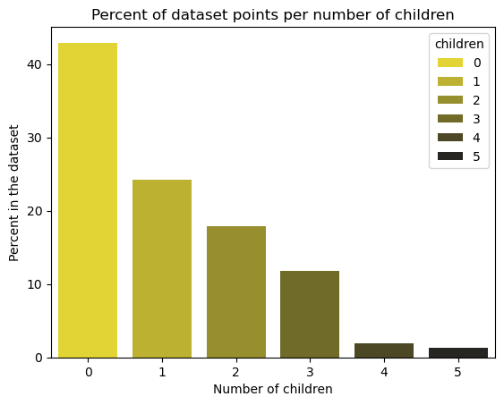

```python
ax = sns.countplot(data=data, x='children', hue='children',
                   palette=colors_children, stat='percent')
ax.set(xlabel='Number of children', ylabel='Percent in the dataset',
       title='Percent of dataset points per number of children')
```

We can see that the percentage of people in the dataset with more than three children is very low. We will keep that in mind when analyzing the dataset.

Also here we can check each age group separately.

```
[Text(0.5, 0, 'Age group'),
```

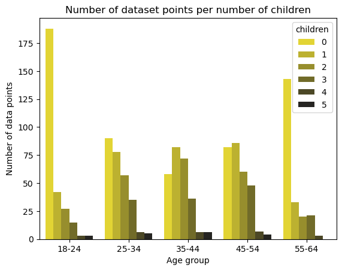

```python
# Number of datapoints of number of children per age group
ax = sns.countplot(data=data, x='age_group', hue='children',
                   palette=colors_children)
ax.set(xlabel='Age group', ylabel='Number of data points',
       title='Number of dataset points per number of children')
```

Finally, we check the distribution of BMI in the dataset

```
[Text(0.5, 0, 'BMI'),
```

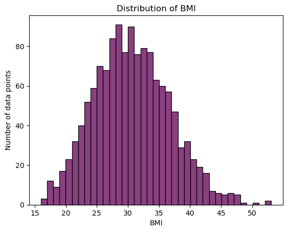

```python
# BMI distribution
ax = sns.histplot(data=data, x='bmi', binwidth=1, color=purple)
ax.set(xlabel='BMI', ylabel='Number of data points',
       title='Distribution of BMI')
```

For a future use, we will arrange the BMI's into larger groups.

```
[Text(0.5, 0, 'BMI'),
```

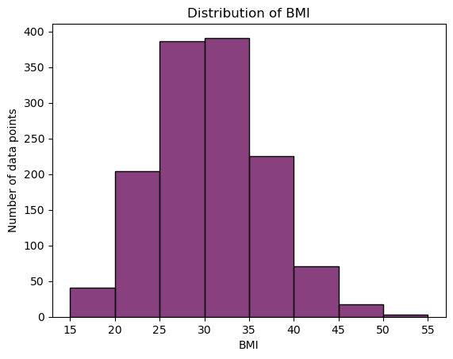

```python
#
bins_bmi = range(15,60,5)
data['bmi_group'] = pd.cut(data['bmi'], bins=bins_bmi, right=False)

ax = sns.histplot(data=data, x='bmi', bins=bins_bmi, color=purple)
ax.set(xlabel='BMI', ylabel='Number of data points',
       title='Distribution of BMI')
```

## What influences the cost of medical insurance?

### Age

```
[Text(0.5, 0, 'Age group'),
```

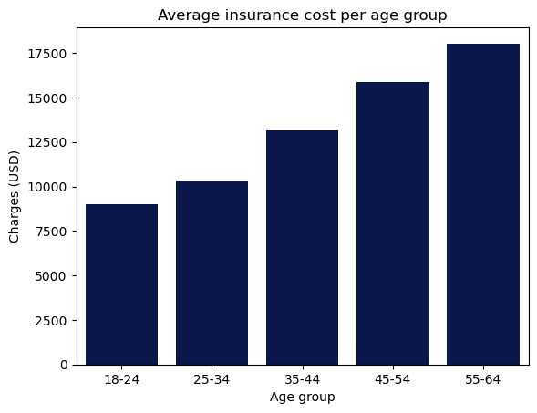

```python
ax = sns.barplot(data=data, x='age_group', y='charges', errorbar=None,
                 color=dark_blue)
ax.set(xlabel='Age group', ylabel='Charges (USD)',
       title='Average insurance cost per age group')
```

The insurance cost clearly increases with age. Let's inspect it further.

```
[Text(0.5, 0, 'Age'),
```

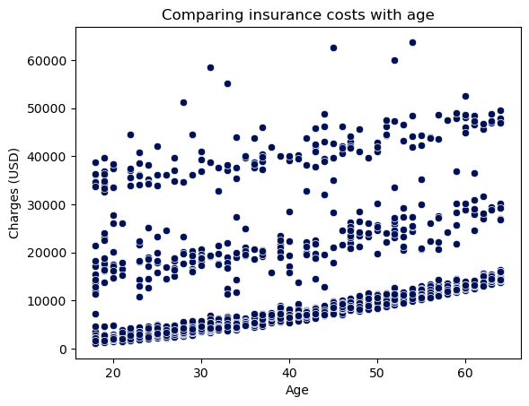

```python
ax = sns.scatterplot(data=data, x='age', y='charges', color=dark_blue)
ax.set(xlabel='Age', ylabel='Charges (USD)',
       title='Comparing insurance costs with age')
```

We see three "lines". What can they be?

```
[Text(0.5, 0, 'Age'),
```

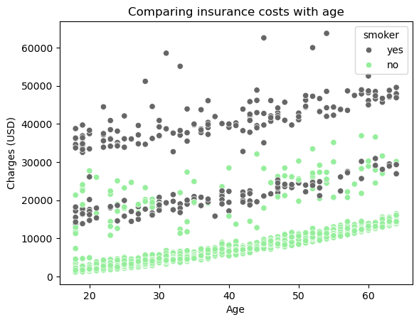

```python
ax = sns.scatterplot(data=data, x='age', y='charges', hue='smoker',
                     palette=colors_smokers)
ax.set(xlabel='Age', ylabel='Charges (USD)',
       title='Comparing insurance costs with age')
```

It seems that large part can be explained by smoking, but the middle "line" is still mysterious.

### Sex

```
Average cost is USD 12569.58  for women and USD 13956.75 for men.
It means that on average, men pay USD 1387.17 more than women.
```

```
[Text(0.5, 0, ''),
```

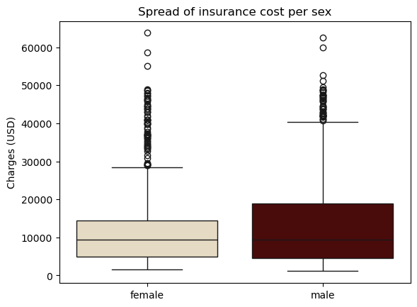

```python
mean_charges_female = data[data['sex'] == 'female']['charges'].mean()
mean_charges_male = data[data['sex'] == 'male']['charges'].mean()
print('Average cost is USD {w}  for women and USD {m} for men. ' \
        '\nIt means that on average, men pay USD {d} more than women.'.format(
            w=round(mean_charges_female,2),
            m=round(mean_charges_male,2),
            d=round(mean_charges_male,2)-round(mean_charges_female,2)
            )
    )

ax = sns.boxplot(data, x='sex', y='charges',
    hue='sex', palette=colors_sex)
ax.set(xlabel = None, ylabel='Charges (USD)',
       title='Spread of insurance cost per sex')
```

### Smoking

```
Average cost is USD 32050.23  for smokers and USD 8434.27 for nonsmokers.
It means that on average, smokers pay USD 23615.96 more than nonsmokers.
```

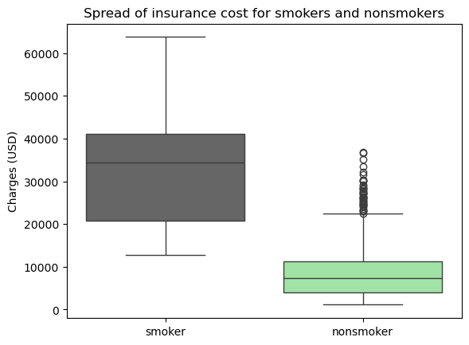

```python
mean_charges_smoker = data[data['smoker'] == 'yes']['charges'].mean()
mean_charges_nonsmoker = data[data['smoker'] == 'no']['charges'].mean()
print('Average cost is USD {y}  for smokers and USD {n} for nonsmokers. ' \
        '\nIt means that on average, smokers pay USD {d} more than nonsmokers.'.format(
            y=round(mean_charges_smoker,2),
            n=round(mean_charges_nonsmoker,2),
            d=round(mean_charges_smoker,2)-round(mean_charges_nonsmoker,2)
            )
    )


ax = sns.boxplot(data, x='smoker', y='charges',
    hue='smoker', palette=colors_smokers)
ax.set(xlabel=None, ylabel='Charges (USD)',
       title='Spread of insurance cost for smokers and nonsmokers')
ax.set_xticks([0,1], labels=['smoker', 'nonsmoker'])
```

We saw that men pay slightly higher insurance costs. Now we know that smokers pay a significantly higher insurance cost. Can the difference between the sexes be explained by larger proportion of smoking men than women?

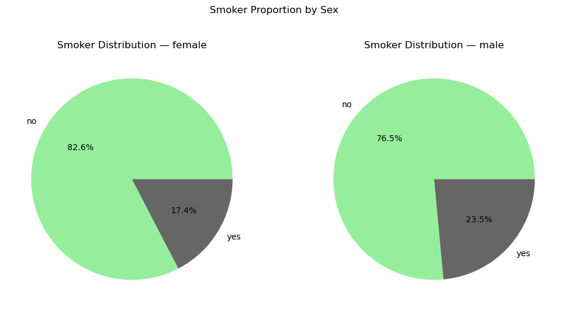

```python
fig, axes = plt.subplots(1, 2, figsize=(12, 6))

for ax, (sex, group) in zip(axes, data.groupby('sex')):
    counts = group['smoker'].value_counts()
    ax.pie(
        counts,
        labels=counts.index,
        autopct='%1.1f%%',
        colors=[light_green, dark_grey]
    )
    ax.set_title(f'Smoker Distribution — {sex}')

plt.suptitle('Smoker Proportion by Sex')
plt.show()
```

There are indeed more smokers among men than among women.

### BMI

```
[Text(0.5, 0, 'BMI'),
```

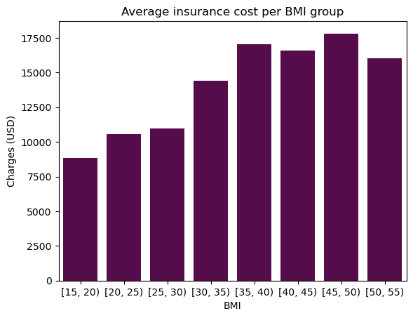

```python
ax = sns.barplot(data=data, x='bmi_group', y='charges', errorbar=None,
                 color=purple)
ax.set(xlabel='BMI', ylabel='Charges (USD)',
       title='Average insurance cost per BMI group')
```

In the rough division into groups, it seems that the charges increase with raising BMI. Let's look at it in more detail.

```
[Text(0.5, 0, 'BMI'),
```

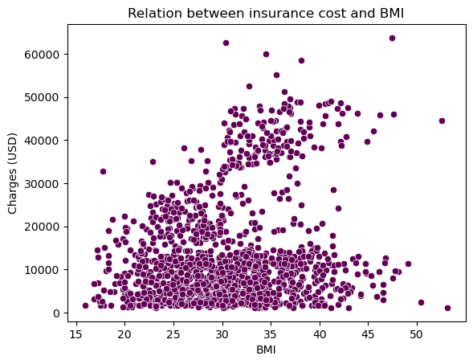

```python
ax = sns.scatterplot(data=data, x='bmi', y='charges', color=purple)
ax.set(xlabel='BMI', ylabel='Charges (USD)',
       title='Relation between insurance cost and BMI')
```

There seem to be two separate groups. Let's try to identify them. Could it be smoking?

```
[Text(0.5, 0, 'BMI'),
```

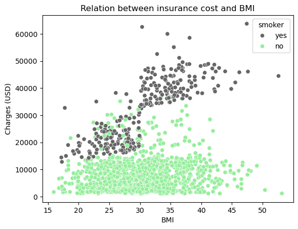

```python
ax = sns.scatterplot(data=data, x='bmi', y='charges', hue='smoker',
                     palette=colors_smokers)
ax.set(xlabel='BMI', ylabel='Charges (USD)',
       title='Relation between insurance cost and BMI')
```

We see that the increase in cost with higher BMI is mostly created by smokers.

### Number of children

```
[Text(0.5, 0, 'Number of children'),
```

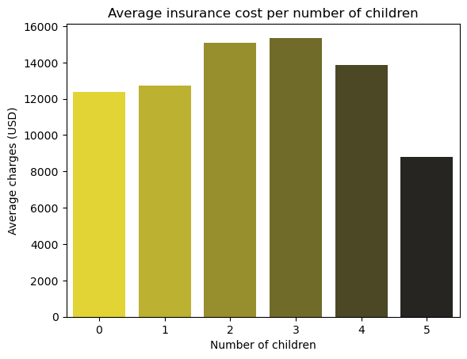

```python
ax = sns.barplot(data=data, x='children', y='charges', errorbar=None,
                 hue='children', palette=colors_children, legend=False)
ax.set(xlabel='Number of children', ylabel='Average charges (USD)',
       title='Average insurance cost per number of children')
```

The insurance cost does not seem to change significantly with the number of children. (Recall that we have few datapoints with more than three children.) Just out of interest, let's again divide the data into age groups.

```
[Text(0.5, 0, 'Age group'),
```

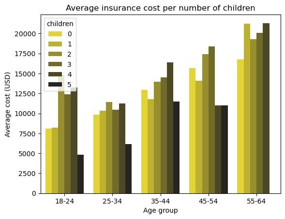

```python
ax = sns.barplot(data=data, x='age_group', y='charges', errorbar=None,
                 hue='children', palette=colors_children)
ax.set(xlabel='Age group', ylabel='Average cost (USD)',
       title='Average insurance cost per number of children')
```

### Correlations

So far, we have seen that the most significant factor seems to be smoking. Let's check if we missed something. (Note that Pearson correlation works only with numerical variables. In order to apply it to the smoker and sex columns, we have to map the binary options into 0 and 1.)

```
[Text(0.5, 1.0, 'Pearson correlation')]
```

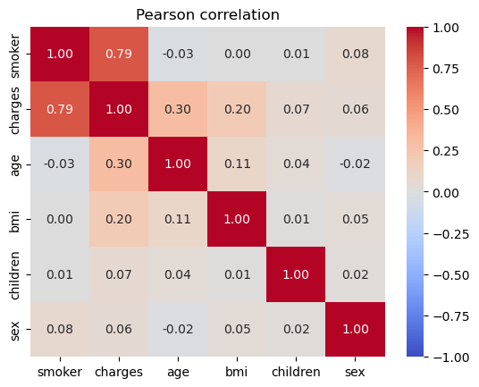

```python
# Replacing categorical variables with numerical
# Necessary for Pearson correlation
data_encoded = data.copy()[[
    'smoker', 'charges', 'age', 'bmi', 'children', 'sex'
    ]]
data_encoded['smoker'] = data_encoded['smoker'].map({'yes': 1, 'no': 0})
data_encoded['sex'] = data_encoded['sex'].map({'male': 1, 'female': 0})

ax = sns.heatmap(data_encoded.corr(), annot=True, fmt='.2f', vmin=-1, vmax=1,
                 cmap=sns.color_palette('coolwarm', as_cmap=True))
ax.set(title='Pearson correlation')
```

We see that the only strong linear correlation is between smoking status and charges. Then there are weak linear correlation between age and charges and between bmi and charges. All of these we have addressed above.

## Conclusion

We conclude that the insurance charges increase with age and that smokers pay significantly more than nonsmokers.

```
[Text(0.5, 0, 'Age group'),
```

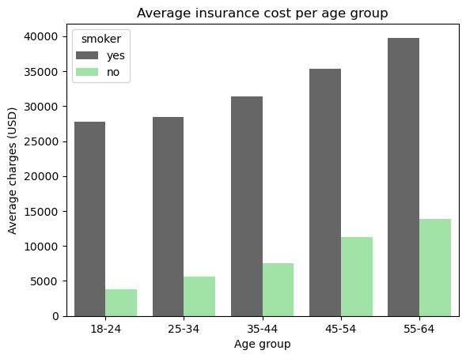

```python
data_avg_charges_smoker_age = data.groupby(
    ['age_group', 'smoker'], observed=True
    )['charges'].mean()


ax = sns.barplot(data=data, x='age_group', y='charges', errorbar=None,
    hue='smoker', palette=colors_smokers)
ax.set(xlabel='Age group', ylabel='Average charges (USD)',
       title='Average insurance cost per age group')
```